# Raster Data Homework

Does climate shape genetic variation in a beetle and a plant?

Author

Published

October 27, 2026

Abstract

## The Idea

One of the central habits of reproducible research is that the **words and the code that produce them are written together**. A paragraph of *Methods* is followed immediately by the chunk that carries out what it describes. A sentence in *Results* is backed by a figure or value generated in the chunk beside it, and every number that appears in the running text is read straight from a variable in memory with an inline `` `r ` `` expression — never typed by hand.

This topic also had a workflow of its own. Nearly every analysis with raster data comes down to the same four steps:

1. **Get** the raster (from a file, a URL, or a package like `geodata`).
2. **Manipulate** it, at the very least cropping it to your study area.
3. **Plot** it, usually with your sample sites on top.
4. **Extract** values from it at your sites, for display or for downstream analysis.

The worked example below runs through all four with the elevation raster we used in the narrative (`alt_22`) and asks whether elevation is related to the sex ratio (`MFRatio`) of the bark beetle *Araptus attenuatus* at each of its 31 sampling sites. Your job is to do the same thing with **climate** (annual mean temperature and annual precipitation from the WorldClim bioclim data) and ask whether climate is related to the **genetic variation** at each site, both in the beetle and in the plant *Euphorbia lomelii*.

## A Worked Example

### Methods

> **Data.** We used the sex ratio (males/females, `MFRatio`) of *Araptus attenuatus* at 31 sites in Baja California and Sonora, stored as a CSV in the course data repository, and converted the site coordinates into spatial points (longitude/latitude, WGS 84). For elevation, we used a 30 arc-second (about 1km) elevation raster, also from the course data repository, and cropped it to the region from 116°W to 109°W and 22°N to 30°N.

```r
library( terra )
library( tidyterra )
library( sf )
library( tidyverse )

beetle_url <- "https://dyerlabteaching.github.io/CourseData/Spatial/AraptusDispersalBias.csv"
read_csv( beetle_url ) |>
  st_as_sf( coords = c("Longitude", "Latitude"),
            crs = 4326 ) -> beetles

# 1. Get
elev <- rast( "https://dyerlabteaching.github.io/CourseData/Spatial/alt_22.tif" )

# 2. Manipulate
baja_extent <- ext( c(-116, -109, 22, 30) )
elev |>
  crop( baja_extent ) |>
  rename( Elevation = alt_22 ) -> baja_elev
```

> **Analysis.** We mapped elevation across the region along with the sampling sites, extracted the elevation at each site, and tested for an association between sex ratio and elevation with a Pearson product-moment correlation using `cor.test()`.

```
<SpatRaster> resampled to 500472 cells.
```

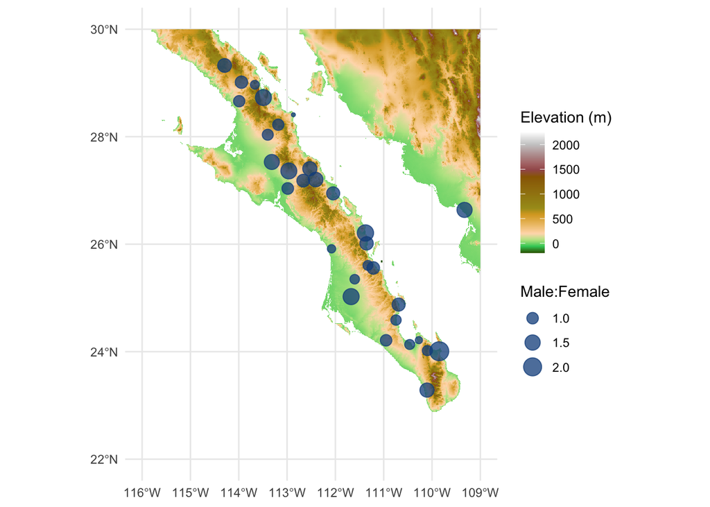

Figure 1: Elevation (m) across southern Baja California and Sonora. Points are the 31 sampling sites for *Araptus attenuatus*, sized by the male:female sex ratio.

```r
# 3. Plot
ggplot() +
  geom_spatraster( data = baja_elev ) +
  scale_fill_hypso_c( na.value = NA ) +
  geom_sf( aes( size = MFRatio ),
           data = beetles,
           color = "dodgerblue4",
           alpha = 0.75 ) +
  labs( fill = "Elevation (m)",
        size = "Male:Female" ) +
  theme_minimal()
```

```r
# 4. Extract
site_elev <- terra::extract( baja_elev, vect(beetles), ID = FALSE )
beetles |>
  mutate( Elevation = site_elev$Elevation ) -> beetles

fit <- cor.test( beetles$MFRatio, beetles$Elevation )
fit
```

```
    Pearson's product-moment correlation

data:  beetles$MFRatio and beetles$Elevation
t = -0.55949, df = 29, p-value = 0.5801
alternative hypothesis: true correlation is not equal to 0
95 percent confidence interval:
 -0.4415112  0.2605426
sample estimates:
       cor
-0.1033377
```

### Preparing the reporting values

Before writing the Results, pull the numbers you are going to report into one small chunk and give each a short name. That way the Results paragraph has no `format()` calls in it and reads almost exactly like the rendered sentence.

```r
N        <- nrow( beetles )
min_elev <- min( beetles$Elevation )
max_elev <- max( beetles$Elevation )

r <- format( fit$estimate,  digits = 3 )
t <- format( fit$statistic, digits = 3 )
p <- format( fit$p.value,   digits = 3 )
```

### Results

> The 31 sites ranged from 6 m to 681 m in elevation, all in the lowlands and foothills of the region (Figure 1). There was no significant association between sex ratio and elevation (Pearson correlation, *r* = -0.103, *t* = -0.559, *P* = 0.58).

Here is the literal source of that Results paragraph — note that every number is an inline expression:

```
The `r N` sites ranged from `r min_elev` m to `r max_elev` m in elevation, all in the lowlands and foothills of the region (@fig-elevation). There was no significant association between sex ratio and elevation (Pearson correlation, *r* = `r r`, *t* = `r t`, *P* = `r p`).
```

## Your Assignment

The beetle data set has two more columns we have not used yet: `GenVarArapat` is the genetic variation of *Araptus attenuatus* at each sampling site, and `GenVarEuphli` is the genetic variation of the plant *Euphorbia lomelii* at the same sites. Repeat the four steps with **climate** in place of elevation, using annual mean temperature (`bio_1`, °C) and annual precipitation (`bio_12`, mm) from the WorldClim bioclim variables, and test whether either one is related to genetic variation in the beetle or in the plant.[^1]

To get the climate data, download the 30 arc-second bioclim tile that covers Baja California with `geodata`:

```r
library( geodata )
bio <- worldclim_tile( var = "bio",
                       lon = -112,
                       lat = 26,
                       path = "data" )
```

The tile is about 126 MB, so the first time you run this it will take a minute or so. It is saved into a `data` folder in your project, and every time after that `worldclim_tile()` finds the file there and loads it without downloading it again. The tile has the same extent and resolution as `alt_22`, so everything in the worked example carries over.

### Your document must have

1. **Methods** — a *Data* paragraph (the sampling sites and their genetic variation, and the WorldClim climate data with its citation[^2]) followed by the chunk that loads the site data, downloads the bioclim tile (**get**), and crops it to the same region keeping just the two layers you need (**manipulate**).
2. **Two maps** (**plot**) — one of annual mean temperature and one of annual precipitation across the region, each with the sampling sites on top and each with a color palette you chose for that variable (not the default).
3. **An *Analysis* paragraph** followed by the chunk that extracts the climate values at each site (**extract**) and tests each of the two genetic variation measures against each of the two climate variables (four tests in all).
4. **A table** summarizing the results of all four tests.
5. **A figure** of genetic variation as a function of the local climate for any test that turns out to be significant.
6. **A reporting-values chunk** — `format()` the numbers you quote in the Results, and give each a short name.
7. **Results** — a paragraph that reports your numbers as bare inline `` `r ` `` values (no `format()` in the prose) and refers to your maps, table, and figure(s) using Quarto’s cross-reference system.[^3]
8. **An interpretation** — a paragraph on what your results say about climate and genetic variation in these two species. Do they respond to climate in the same way?

Then answer briefly, a sentence or two each:

- Which *kind* of palette (sequential, diverging, or qualitative) did you use for each map, and why does it fit that variable?
- Each climate value you extracted comes from a single cell about 1km on a side. What does that one number actually represent for the beetles or plants at that site, and when could that be misleading?

## What You Turn In

**One file: the rendered, self-contained `.html`.** Not the `.qmd`, and not a copy of this page. Make a *new* Quarto document that contains only your own work — your Methods and Results sections with their chunks, your maps, table, and figure(s), the reporting-values chunk, your interpretation, and your brief answers to the two questions.

The worked example above is a model to imitate, not text to paste into your document.

### Making the document

1. In RStudio: **File ▸ New File ▸ Quarto Document…**
2. In the dialog, enter a title and your name, leave the engine set to **Knitr**, and click **Create**.
3. Delete everything RStudio puts below the header (the “Quarto” boilerplate and its example chunk).
4. Replace the header it generated with the one below.
5. Save the file into your course project folder as `Raster-Data-Homework.qmd`.
6. Write your content, then click **Render** to produce the `.html`. That HTML file is what you submit.

### The full YAML header

```yaml
---
title: "Raster Data Homework"
author: "Your Name"
date: today
abstract: |
  A sentence or two saying what the document does: the data, the question, and what you found.
format:
  html:
    self-contained: true
    code-tools: true
---
```

- **`title` / `author` / `date` / `abstract`** — complete front matter, including a short summary where a scientific paper would put its abstract. `date: today` fills itself in at render time.
- **`format: html`** — render to a single web page I can open in any browser.
- **`self-contained: true`** — bundle every image, style, and script *into* that one `.html` file. Without it the file depends on a sibling `*_files/` folder that never makes it into the upload, and your figures and formatting arrive broken.
- **`code-tools: true`** — adds the “</> Code” button in the top-right that lets a reader view the full source. **This is not optional.** If I cannot see the code behind a wrong answer, I cannot tell whether you were one typo away or lost the plot entirely — which means I cannot give partial credit, point out where it went sideways, or help you fix it.

Use this same header layout for every document you turn in this course.

## How This Is Graded

This assignment is scored with the **Online Homework Rubric** on the Canvas site — the same rubric used for every online homework in this course. It covers online access to the published document, front matter, formatting, and whether the document stands on its own; the remaining points come from the assignment-specific work above.

## Footnotes

[^1]: Every step is in the module [narrative](https://dyerlabteaching.github.io/Raster-Data/narrative.html): see *Downloading Rasters with `geodata`* for the bioclim data, *Choosing a Color Palette* for palettes, and *Research Question 1* under *Applications* for extracting values and testing them.
[^2]: Fick, S.E. and R.J. Hijmans, 2017. WorldClim 2: new 1km spatial resolution climate surfaces for global land areas. *International Journal of Climatology* 37 (12): 4302–4315.
[^3]: Cross-referencing tables is in the [Tidyverse](https://dyerlabteaching.github.io/Tidyverse/narrative.html#cross-referencing-tables-in-text) narrative; figures work the same way with a `fig-` label and a `fig-cap`.